# Plot ASR pheontypic results

Bin He

2023-1-1 (updated 2023-04-10)

```r
require(tidyverse)
require(cowplot)
require(broom)
set.seed(12345)
```

## Introduction

### Goal

Plotting ASR data for Fig. 1, S1, …

### Data

Read in data

```r
tmp <- read_tsv("../input/20220726-ASR-CFU-raw.tsv", col_types = cols(), comment = "#")
raw <- read_csv("../input/20221224-ASR-CFU-raw.csv", col_types = cols(), comment = "#") %>%
  mutate(Date = gsub("d(\\d\\d)(\\d\\d)(\\d\\d)", "\\1/\\2/\\3", Date),
         Len_1 = recode(Len_1, `2hr` = "2 hr", `45min` = "45 min"),
         Len_2 = recode(Len_2, `2hr` = "2 hr")) %>%
  select(-`MO/MM`, -`PO/PM`) %>%
  bind_rows(add_column(tmp, Experimenter = "JL"))

# data sanity check, quick view
sapply(select(raw, Species, Strain, Genotype, Len_1, Len_2, H2O2), unique)
```

```
$Species
[1] "Cg" "Sc" "Kl"

$Strain
 [1] "yH001" "yH154" "yH181" "yH149" "yH002" "yH609" "yH610" "yH271" "yH272" "yH273" "yH262" "yH275"

$Genotype
[1] "wt"         "rim15Δ"     "cta1Δ"      "msn2Δ"      "msn4Δ"      "msn2Δmsn4Δ"

$Len_1
[1] "45 min"  "2hr"     "90 min"  "135 min"

$Len_2
[1] "2 hr"  "0 min"

$H2O2
 [1] "Mock"   "20mM"   "40mM"   "60mM"   "80mM"   "100mM"  "2mM"    "4mM"    "6mM"    "8mM"    "10mM"   "15mM"   "25mM"
[14] "30mM"   "35mM"   "1.5mM"  "2.5mM"  "3mM"    "3.5mM"  "0.5mM"  "1mM"    "0.2mM"  "0.3mM"  "0.4mM"  "0.26mM" "0.34mM"
[27] "0 mM"   "20 mM"  "40 mM"  "60 mM"  "80 mM"  "100 mM" "2.2 mM" "2.5 mM" "2 mM"   "4 mM"   "6 mM"   "8 mM"   "10 mM"
```

### Common plotting functions

```r
species.label <- c(Sc = "S. cerevisiae", Cg = "C. glabrata")

p.survival <- list(
  geom_point(shape = 1, stroke = 1, size = 2,
             position = position_jitter(width = 0.15)),
  stat_summary(fun = mean, fun.max = mean, fun.min = mean,
               geom = "crossbar", color = "red", width = 0.5),
  facet_wrap(~Species, scales = "free_x", labeller = as_labeller(species.label)),
  theme_cowplot(line_size = 0.7, font_size = 14),
  theme(strip.text = element_text(size = rel(1), face = 3))
)

p.asr <- list(
  geom_hline(yintercept = 1, linetype = 2, color = "gray50"),
  geom_point(position = position_jitter(width = 0.1), size = 2),
  stat_summary(fun.data = "mean_cl_boot", geom = "pointrange", color = "red",
               position = position_nudge(x = 0.2)),
  facet_wrap(~Species, scales = "free_x", labeller = as_labeller(species.label)),
  theme_cowplot(line_size = 0.7),
  theme(strip.text = element_text(size = rel(1.1), face = 3))
)
```

## Fig1: ASR between species

**Goal**

- Compare the ASR effect between *S. cerevisiae* and *C. glabrata* at 10 mM and 100 mM [H2O2], respectively.

**Experiment**

Jinye has performed several experiments at these two concentrations, as shown below

```r
raw %>%
  filter(Genotype == "wt", H2O2 %in% c("10mM", "10 mM", "100mM", "100 mM"),
         Len_1 == "45 min", Group == "PO") %>%
  mutate(group = paste(recode(Strain, yH154 = "Sc", yH001 = "Cg1", yH002 = "Cg2"),
                       gsub(" ?mM", "", H2O2), sep = "_")) %>%
  count(Date, group) %>%
  pivot_wider(names_from = group, values_from = n)
```

| Date | Cg1_100 | Sc_10 | Cg2_100 |
| --- | --- | --- | --- |
| 05/30/20 | 3 | 3 | NA |
| 06/01/20 | 3 | 3 | NA |
| 06/04/20 | 3 | 3 | NA |
| 06/06/20 | 3 | 3 | NA |
| 06/16/22 | 1 | NA | NA |
| 06/20/22 | 1 | NA | NA |
| 06/24/22 | 1 | NA | NA |
| 06/28/22 | 1 | NA | 1 |
| 06/29/22 | 1 | NA | 1 |
| 07/02/22 | 1 | NA | 1 |

[output cut: 13 more lines]

We will use the 05/30/20, 06/01/20 and 06/04/20 data, which were three consecutive replicates meant to compare the ASR under -Pi between the two species. The other datasets were part of an experiment with different purposes.

**Data**

**Main dataset**:

[output not shown]

**Note**: one replicate for Sc on 05/30/20 showed much lower CFU numbers than the other plates.

```r
filter(raw, Date == "05/30/20", Species == "Sc")
```

| Date | Strain | Species | Genotype | Group | Len_1 | Len_2 | H2O2 | Dilutions | Count | Experimenter |
| --- | --- | --- | --- | --- | --- | --- | --- | --- | --- | --- |
| 05/30/20 | yH154 | Sc | wt | MM | 45 min | 2 hr | 0 mM | 2500 | 307 | JL |
| 05/30/20 | yH154 | Sc | wt | MM | 45 min | 2 hr | 0 mM | 2500 | 52 | JL |
| 05/30/20 | yH154 | Sc | wt | MM | 45 min | 2 hr | 0 mM | 2500 | 297 | JL |
| 05/30/20 | yH154 | Sc | wt | PM | 45 min | 2 hr | 0 mM | 2500 | 374 | JL |
| 05/30/20 | yH154 | Sc | wt | PM | 45 min | 2 hr | 0 mM | 2500 | 150 | JL |
| 05/30/20 | yH154 | Sc | wt | PM | 45 min | 2 hr | 0 mM | 2500 | 306 | JL |
| 05/30/20 | yH154 | Sc | wt | MO | 45 min | 2 hr | 10 mM | 40 | 451 | JL |
| 05/30/20 | yH154 | Sc | wt | MO | 45 min | 2 hr | 10 mM | 40 | 371 | JL |
| 05/30/20 | yH154 | Sc | wt | MO | 45 min | 2 hr | 10 mM | 40 | 386 | JL |
| 05/30/20 | yH154 | Sc | wt | PO | 45 min | 2 hr | 10 mM | 40 | 360 | JL |

[output cut: 2 more lines]

Jinye removed the second replicate for both Sc and Cg from her downstream analyses.

Below are the filtered data:

```r
use.f1 <- paste0(c("06/04", "06/01", "05/30"), "/20")
tmp <-  raw %>%
  filter(Date %in% use.f1) %>%
  mutate(
    scaled = Count * Dilutions * 1e-2
  ) %>%
  # remove uninformative columns. only one H2O2 conc used for each species
  select(-Strain, -Genotype, -H2O2, -Len_1, -Len_2, -Experimenter)

# Assume the triplicates were paired in the order they appear in the table,
# i.e., the first row in the MO, MM, PO, PM groups belong to the same biological
# replicate, we can derive three ASR_scores for each date x species x Len_1

dat.f1 <- tmp %>%
  group_by(Date, Species, Group) %>%
  mutate(Repl = row_number()) %>%
  # group by primary to calculate r (MO/MM) or r' (PO/PM)
  separate(Group, into = c("Primary", "Secondary"), sep = 1) %>%
  group_by(Date, Species, Repl, Primary) %>%
  # calculate % survival
  mutate(r = num(scaled / scaled[Secondary == "M"], digits = 3)) %>%
  # remove the secondary mock as the information are all used
  filter(Secondary != "M") %>%
  # 5/30/20 replicate 2 is excluded
  filter(!(Date == "05/30/20" & Repl == 2))
dat.f1
```

| Date | Species | Primary | Secondary | Dilutions | Count | scaled | Repl | r |
| --- | --- | --- | --- | --- | --- | --- | --- | --- |
| 06/04/20 | Cg | M | O | 100 | 203 | 203.0 | 1 | 0.012 |
| 06/04/20 | Cg | M | O | 100 | 94 | 94.0 | 2 | 0.006 |
| 06/04/20 | Cg | M | O | 100 | 271 | 271.0 | 3 | 0.017 |
| 06/04/20 | Cg | P | O | 100 | 1002 | 1002.0 | 1 | 0.066 |
| 06/04/20 | Cg | P | O | 100 | 391 | 391.0 | 2 | 0.030 |
| 06/04/20 | Cg | P | O | 100 | 656 | 656.0 | 3 | 0.043 |
| 06/04/20 | Sc | M | O | 40 | 57 | 22.8 | 1 | 0.003 |
| 06/04/20 | Sc | M | O | 40 | 116 | 46.4 | 2 | 0.005 |
| 06/04/20 | Sc | M | O | 40 | 128 | 51.2 | 3 | 0.005 |
| 06/04/20 | Sc | P | O | 40 | 94 | 37.6 | 1 | 0.005 |

[output cut: 22 more lines]

**Plotting**

#### Plot

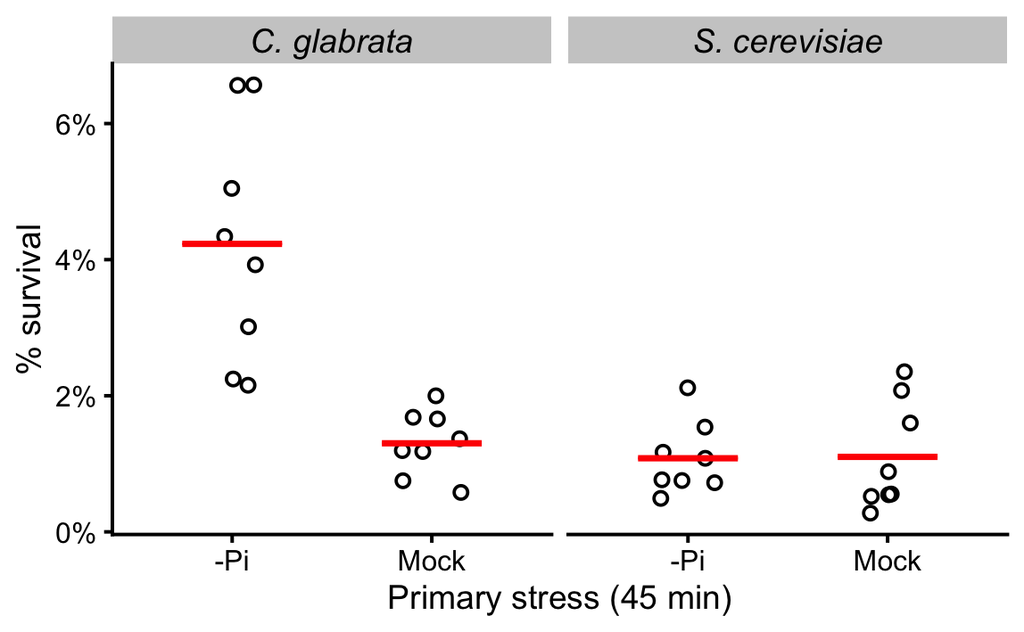

```r
dat.f1 %>%
  mutate(Primary = recode(Primary, M = "Mock", P = "-Pi")) %>%
  ggplot(aes(x = Primary, y = r)) + p.survival +
  scale_y_continuous(labels = scales::percent) +
  xlab("Primary stress (45 min)") + ylab("% survival")

ggsave("../output/20230228-fig1d-asr-noPi-compare.png", width = 3.5, height = 3)
```

**Statistical tests**

#### Statistical tests

1. Determine if the basal survival rates are different between species (Wilcoxon signed-rank test)
2. Determine if the primary stress enhanced the survival in *each* species (Wilcoxon signed-rank test)

*Basal survival rate*

The basal survival rates between species within the same day are not “paired”. We will use a rank-sum test here.

```r
tmp <- dat.f1 %>%
  filter(Primary == "M") %>%
  pivot_wider(id_cols = c(Date, Repl), names_from = Species, values_from = r)
tmp
```

| Date | Repl | Cg | Sc |
| --- | --- | --- | --- |
| 06/04/20 | 1 | 0.012 | 0.003 |
| 06/04/20 | 2 | 0.006 | 0.005 |
| 06/04/20 | 3 | 0.017 | 0.005 |
| 06/01/20 | 1 | 0.020 | 0.016 |
| 06/01/20 | 2 | 0.014 | 0.006 |
| 06/01/20 | 3 | 0.012 | 0.009 |
| 05/30/20 | 1 | 0.017 | 0.024 |
| 05/30/20 | 3 | 0.007 | 0.021 |

```r
with(tmp, t.test(as.numeric(Cg), as.numeric(Sc), paired = FALSE))
```

```
    Welch Two Sample t-test

data:  as.numeric(Cg) and as.numeric(Sc)
t = 0.60672, df = 11.515, p-value = 0.5558
alternative hypothesis: true difference in means is not equal to 0
95 percent confidence interval:
 -0.005202894  0.009192871
sample estimates:
 mean of x  mean of y
0.01301413 0.01101914
```

```r
with(tmp, wilcox.test(Cg, Sc, paired = FALSE))
```

```
    Wilcoxon rank sum exact test

data:  Cg and Sc
W = 41, p-value = 0.3823
alternative hypothesis: true location shift is not equal to 0
```

*Primary stress enhanced in Cg*

The comparison between r and r’ is paired. We will use a signed-rank test.

```r
tmp <- dat.f1 %>%
  filter(Species == "Cg") %>%
  pivot_wider(id_cols = c(Date, Repl), names_from = Primary, values_from = r) %>%
  mutate(ASR = P/M)
tmp
```

| Date | Repl | M | P | ASR |
| --- | --- | --- | --- | --- |
| 06/04/20 | 1 | 0.012 | 0.066 | 5.502 |
| 06/04/20 | 2 | 0.006 | 0.030 | 5.226 |
| 06/04/20 | 3 | 0.017 | 0.043 | 2.573 |
| 06/01/20 | 1 | 0.020 | 0.066 | 3.286 |
| 06/01/20 | 2 | 0.014 | 0.022 | 1.575 |
| 06/01/20 | 3 | 0.012 | 0.039 | 3.322 |
| 05/30/20 | 1 | 0.017 | 0.050 | 3.040 |
| 05/30/20 | 3 | 0.007 | 0.022 | 2.998 |

```r
x <- Hmisc::smean.cl.boot(tmp$ASR)
sprintf("ASR_score mean = %.2f, 95%% CI by bootstrap = [%.2f, %.2f]", x[1], x[2], x[3])
```

```
[1] "ASR_score mean = 3.44, 95% CI by bootstrap = [2.66, 4.26]"
```

```r
with(tmp, t.test(as.numeric(P), as.numeric(M), paired = TRUE, alternative = "g"))
```

```
    Paired t-test

data:  as.numeric(P) and as.numeric(M)
t = 5.5041, df = 7, p-value = 0.0004513
alternative hypothesis: true mean difference is greater than 0
95 percent confidence interval:
 0.01921734        Inf
sample estimates:
mean difference
     0.02930431
```

```r
with(tmp, wilcox.test(P, M, paired = TRUE, alternative = "g"))
```

```
    Wilcoxon signed rank exact test

data:  P and M
V = 36, p-value = 0.003906
alternative hypothesis: true location shift is greater than 0
```

*Primary stress no effect in Sc*

```r
tmp <- dat.f1 %>%
  filter(Species == "Sc") %>%
  pivot_wider(id_cols = c(Date, Repl), names_from = Primary, values_from = r) %>%
  mutate(ASR = P/M)

tmp
```

| Date | Repl | M | P | ASR |
| --- | --- | --- | --- | --- |
| 06/04/20 | 1 | 0.003 | 0.005 | 1.785 |
| 06/04/20 | 2 | 0.005 | 0.008 | 1.391 |
| 06/04/20 | 3 | 0.005 | 0.012 | 2.248 |
| 06/01/20 | 1 | 0.016 | 0.007 | 0.451 |
| 06/01/20 | 2 | 0.006 | 0.008 | 1.374 |
| 06/01/20 | 3 | 0.009 | 0.011 | 1.223 |
| 05/30/20 | 1 | 0.024 | 0.015 | 0.655 |
| 05/30/20 | 3 | 0.021 | 0.021 | 1.018 |

```r
x <- Hmisc::smean.cl.boot(tmp$ASR)

sprintf("ASR_score mean = %.2f, 95%% CI by bootstrap = [%.2f, %.2f]", x[1], x[2], x[3])
```

```
[1] "ASR_score mean = 1.27, 95% CI by bootstrap = [0.90, 1.63]"
```

```r
with(tmp, t.test(as.numeric(P), as.numeric(M), paired = TRUE, alternative = "g"))
```

```
    Paired t-test

data:  as.numeric(P) and as.numeric(M)
t = -0.10757, df = 7, p-value = 0.5413
alternative hypothesis: true mean difference is greater than 0
95 percent confidence interval:
 -0.003806367          Inf
sample estimates:
mean difference
  -0.0002045084
```

```r
with(tmp, wilcox.test(P, M, paired = TRUE, alternative = "g"))
```

```
    Wilcoxon signed rank exact test

data:  P and M
V = 21, p-value = 0.3711
alternative hypothesis: true location shift is greater than 0
```

## S1A: Basal H2O2 resistance

**Goal**

- Compare the basal survival rates of the two species at different [H2O2] to identify comparable concentrations for ASR.

**Experiment**

- Jinye measured CFU for *S. cerevisiae* and *C. glabrata* exposed to a range of [H2O2]

**Data**

- Filter the data for the relevant experiments.

**Main dataset**:

| Species | H2O2 | Description |
| --- | --- | --- |
| C. glabrata | 0, 20, 40, 60, 80, 100 mM | Only M and O, no primary stress |
| S. cerevisiae | 0, 2, 4, 6, 8, 10 mM | Only M and O, no primary stress |

| Date | Species | Replicate |
| --- | --- | --- |
| 03/21/22 | Sc, Cg | 1 |
| 03/22/22 | Sc, Cg | 2 |
| 03/24/22 | Sc, Cg | 3 |
| 03/28/22 | Sc, Cg | 4 |
| 04/01/22 | Sc, Cg | 5 |

```r
use.s1 <- paste0(c("03/21", "03/22", "03/24", "03/28", "04/01"), "/22")
dat.s1 <- raw %>% select(-Experimenter, -Len_1, -Len_2, -Genotype) %>%
  mutate(scaled = Count * Dilutions * 1e-3) %>%
  filter(Date %in% use.s1) %>%
  group_by(Date, Strain) %>%
  mutate(r = num(scaled / scaled[Group == "M"], digits = 3)) %>%
  select(-Group)
dat.s1
```

| Date | Strain | Species | H2O2 | Dilutions | Count | scaled | r |
| --- | --- | --- | --- | --- | --- | --- | --- |
| 04/01/22 | yH154 | Sc | 0 mM | 1000 | 301 | 301.0 | 1.000 |
| 04/01/22 | yH154 | Sc | 2 mM | 100 | 474 | 47.4 | 0.157 |
| 04/01/22 | yH154 | Sc | 4 mM | 100 | 360 | 36.0 | 0.120 |
| 04/01/22 | yH154 | Sc | 6 mM | 100 | 260 | 26.0 | 0.086 |
| 04/01/22 | yH154 | Sc | 8 mM | 100 | 202 | 20.2 | 0.067 |
| 04/01/22 | yH154 | Sc | 10 mM | 100 | 150 | 15.0 | 0.050 |
| 04/01/22 | yH001 | Cg | 0 mM | 1000 | 521 | 521.0 | 1.000 |
| 04/01/22 | yH001 | Cg | 20 mM | 1000 | 114 | 114.0 | 0.219 |
| 04/01/22 | yH001 | Cg | 40 mM | 1000 | 95 | 95.0 | 0.182 |
| 04/01/22 | yH001 | Cg | 60 mM | 1000 | 41 | 41.0 | 0.079 |

[output cut: 50 more lines]

```r
write_tsv(dat.s1, file = "../input/20230302-fig-s1a-data-hb.txt")
```

#### Plot

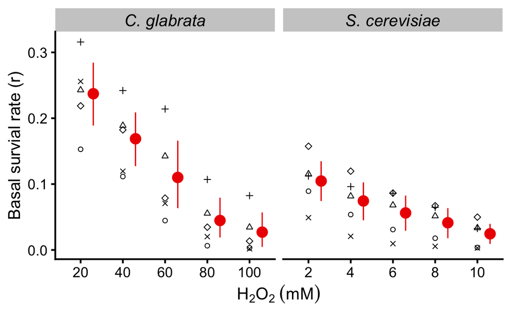

```r
p <- dat.s1 %>%
  mutate(H2O2 = gsub(" mM", "", H2O2),
         H2O2 = fct_reorder(H2O2, as.numeric(H2O2))) %>%
  filter(H2O2 != "0") %>%
  ggplot(aes(x = H2O2, y = r)) +
  geom_point(aes(shape = Date)) +
  #geom_line(aes(group = Date, color = Date), alpha = 0.8) +
  scale_color_brewer(palette = "Dark2") +
  scale_shape_manual(values = 1:5, guide = "none") +
  stat_summary(fun.data = "mean_cl_boot", geom = "pointrange", color = "red2",
               size = 0.8, position = position_nudge(x = 0.3)) +
  facet_wrap(~Species, scales = "free_x", labeller = as_labeller(species.label)) +
  xlab(bquote(H[2]*O[2]~(mM))) + ylab("Basal survial rate (r)") +
  theme_cowplot(line_size = 0.7) +
  theme(strip.text = element_text(size = rel(1), face = 3))
p
ggsave("../output/20230101-basal-survival-across-h2o2-range-sc-cg.png", width = 5, height = 3)
```

#### Statistical tests

Statistical test for difference between species at the highest concentration. Using the Wilcoxon rank-sum test (aka Mann-Whitney’s U test)

```r
tmp <- dat.s1 %>%
  filter(H2O2 %in% c("100 mM", "10 mM"))
tmp %>% group_by(Species) %>% summarize(mean = mean(r))
```

| Species | mean |
| --- | --- |
| Cg | 0.027 |
| Sc | 0.025 |

```r
wilcox.test(r ~ Species, data = tmp, paired = FALSE)
```

```
    Wilcoxon rank sum exact test

data:  r by Species
W = 12, p-value = 1
alternative hypothesis: true location shift is not equal to 0
```

## S1B: ASR at different H2O2

**Goal**

**Data**

**Main dataset**:

| Species | H2O2 | Description |
| --- | --- | --- |
| C. glabrata | 0, 20, 40, 60, 80, 100 mM | full ASR experiment |
| S. cerevisiae | 0, 2, 4, 6, 8, 10mM | full ASR experiment |

| Date | Species | Strain | Replicate |
| --- | --- | --- | --- |
| 07/16/22 | Cg | yH001,2 | a1 |
| 07/17/22 | Cg | yH001,2 | a2 |
| 07/18/22 | Cg | yH001,2 | a3 |
| 07/29/22 | Cg | yH001 | b1 |
| 07/29/22 | Sc | yH154 | b1 |
| 08/01/22 | Cg | yH001 | b2 |
| 08/01/22 | Sc | yH154 | b2 |
| 08/02/22 | Cg | yH001 | b3 |
| 08/02/22 | Sc | yH154 | b3 |
| 08/04/22 | Cg | yH001 | b4 |
| 08/04/22 | Sc | yH154 | b4 |
| 08/11/22 | Cg | yH001 | b5 |
| 08/11/22 | Sc | yH154 | b5 |

```r
use.s1b <- paste0(c("07/16", "07/17", "07/18", "07/29", "08/01", "08/02", "08/04", "08/11"), "/22")
dat.s1b <-  raw %>%
  separate(Group, into = c("Primary", "Secondary"), sep = 1) %>%
  mutate(
    # arbitrarily decide any CFU counts < 3 are not included due to high CV
    Count = ifelse(Count < 3, NA, Count),
    scaled = Count * Dilutions * 1e-3
  ) %>%
  filter(Date %in% use.s1b) %>%
  group_by(Date, Strain, Primary) %>%
  # calculate r and r'
  mutate(r = num(scaled / scaled[Secondary == "M"], digits = 3)) %>%
  # remove the secondary mock as the information are all used
  filter(Secondary != "M") %>%
  pivot_wider(id_cols = c(Date, Strain, Species, H2O2),
              names_from = Primary, values_from = r, names_prefix = "r") %>%
  mutate(ASR_score = rP / rM)

dat.s1b
```

[output not shown]

[output cut: 70 more lines]

```r
write_tsv(dat.s1b, file = "../input/20230302-fig-s1b-data-hb.tsv")
```

#### Plot

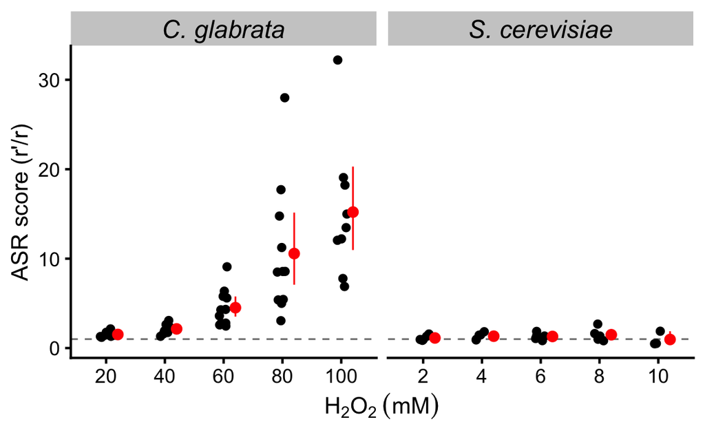

```r
p <- dat.s1b %>%
  filter(!is.na(ASR_score)) %>%
  mutate(H2O2 = gsub(" ?mM", "", H2O2),
         H2O2 = fct_reorder(H2O2, as.numeric(H2O2))) %>%
  filter(H2O2 != "0") %>%
  ggplot(aes(x = H2O2, y = ASR_score)) + p.asr +
  #geom_hline(yintercept = 1, linetype = 2, color = "gray50") +
  #geom_point(position = position_jitter(width = 0.1), alpha = 0.8) +
  #stat_summary(fun.data = "mean_cl_boot", geom = "pointrange", color = "red",
  #             size = 0.8, position = position_nudge(x = 0.2)) +
  #scale_y_log10() +
  #facet_wrap(~Species, scales = "free_x", labeller = as_labeller(species.label)) +
  xlab(bquote(H[2]*O[2]~(mM))) + ylab("ASR score (r'/r)")# +
  #theme_cowplot(line_size = 0.7) +
  #theme(strip.text = element_text(size = rel(1), face = 3))
p
ggsave("../output/20230102-ASR-score-across-h2o2-range-sc-cg.png", width = 5, height = 3)
```

#### Statistical summary

```r
dat.s1b %>%
  filter(!is.na(ASR_score)) %>%
  mutate(H2O2 = gsub(" ?mM", "", H2O2),
         H2O2 = fct_reorder(H2O2, as.numeric(H2O2))) %>%
  filter(H2O2 != "0") %>%
  group_by(Species, H2O2) %>%
  summarise(rM = mean(rM), ASR = mean(ASR_score), sd_asr = sd(ASR_score))
```

| Species | H2O2 | rM | ASR | sd_asr |
| --- | --- | --- | --- | --- |
| Cg | 20 | 0.224 | 1.524 | 0.2769172 |
| Cg | 40 | 0.148 | 2.146 | 0.5083993 |
| Cg | 60 | 0.065 | 4.518 | 2.0468452 |
| Cg | 80 | 0.026 | 10.568 | 7.2486101 |
| Cg | 100 | 0.010 | 15.209 | 7.5781597 |
| Sc | 2 | 0.064 | 1.131 | 0.3019590 |
| Sc | 4 | 0.051 | 1.331 | 0.3795894 |
| Sc | 6 | 0.043 | 1.301 | 0.3872579 |
| Sc | 8 | 0.021 | 1.493 | 0.7355726 |
| Sc | 10 | 0.018 | 0.962 | 0.7995349 |

## S2: ASR at different primary stress duration

**Goal**

**Data**

**Main dataset**:

| Species | Len_noPi | H2O2 | Description |
| --- | --- | --- | --- |
| C. glabrata | 45, 90, 135 min | 100 mM | full ASR experiment |
| S. cerevisiae | 45, 90, 135 min | 10mM | full ASR experiment |

| Date | Species | Len_noPi | Strain |
| --- | --- | --- | --- |
| 06/06/20 | Cg | 45 min | yH001 |
| 06/06/20 | Sc | 45 min | yH154 |
| 06/06/20 | Cg | 90 min | yH001 |
| 06/06/20 | Sc | 90 min | yH154 |
| 06/06/20 | Cg | 135 min | yH001 |
| 06/06/20 | Sc | 135 min | yH154 |

**Supporting dataset**:

[output not shown]

```r
use.s2 <- paste0(c("06/06", "06/04", "06/01", "05/30"), "/20")
tmp <-  raw %>%
  filter(Date %in% use.s2) %>%
  mutate(
    # arbitrarily decide any CFU counts < 3 are not included due to high CV
    # not in use here. instead, label them in the plot (see below)
    # count = ifelse(Count < 3, NA, Count),
    scaled = Count * Dilutions * 1e-2
  ) %>%
  # remove uninformative columns. only one H2O2 conc used for each species
  select(-Strain, -Genotype, -H2O2, -Len_2, -Experimenter)
```

Assume the triplicates were paired in the order they appear in the table, i.e., the first row in the MO, MM, PO, PM groups belong to the same biological replicate, we can derive three ASR_scores for each date x species x Len_1

```r
dat.s2 <- tmp %>%
  group_by(Date, Species, Len_1, Group) %>%
  mutate(Repl = row_number()) %>%
  pivot_wider(id_cols = c(Date, Species, Len_1, Repl),
              names_from = Group, values_from = scaled, names_sep = "") %>%
  mutate(
    r = MO/MM,
    rp = PO/PM,
    ASR_score = rp/r,
    low_count = MO < 1 # mark experiments with < 3 counts
  )
dat.s2
```

| Date | Species | Len_1 | Repl | MM | PM | MO | PO | r | rp | ASR_score | low_count |
| --- | --- | --- | --- | --- | --- | --- | --- | --- | --- | --- | --- |
| 06/06/20 | Cg | 90 min | 1 | 11400 | 5950 | 11.0 | 664.0 | 9.649123e-04 | 1.115966e-01 | 115.6546982 | FALSE |
| 06/06/20 | Cg | 90 min | 2 | 7325 | 4525 | 10.0 | 629.0 | 1.365188e-03 | 1.390055e-01 | 101.8215470 | FALSE |
| 06/06/20 | Cg | 90 min | 3 | 10225 | 6925 | 11.0 | 852.0 | 1.075795e-03 | 1.230325e-01 | 114.3642927 | FALSE |
| 06/06/20 | Sc | 90 min | 1 | 1375 | 3950 | 0.4 | 0.8 | 2.909091e-04 | 2.025316e-04 | 0.6962025 | TRUE |
| 06/06/20 | Sc | 90 min | 2 | 5975 | 1775 | 1.6 | 9.2 | 2.677824e-04 | 5.183099e-03 | 19.3556338 | FALSE |
| 06/06/20 | Sc | 90 min | 3 | 2375 | 525 | 2.0 | 5.6 | 8.421053e-04 | 1.066667e-02 | 12.6666667 | FALSE |
| 06/06/20 | Cg | 135 min | 1 | 16575 | 11875 | 14.0 | 1436.0 | 8.446456e-04 | 1.209263e-01 | 143.1681203 | FALSE |
| 06/06/20 | Cg | 135 min | 2 | 21000 | 10625 | 22.0 | 1329.0 | 1.047619e-03 | 1.250824e-01 | 119.3967914 | FALSE |
| 06/06/20 | Cg | 135 min | 3 | 19025 | 11950 | 10.0 | 1546.0 | 5.256242e-04 | 1.293724e-01 | 246.1309623 | FALSE |
| 06/06/20 | Sc | 135 min | 1 | 8450 | 7650 | 0.4 | 0.8 | 4.733728e-05 | 1.045752e-04 | 2.2091503 | TRUE |

[output cut: 26 more lines]

```r
write_tsv(dat.s2, file = "../input/20230302-fig-s2-data-hb.tsv")
```

#### Plot

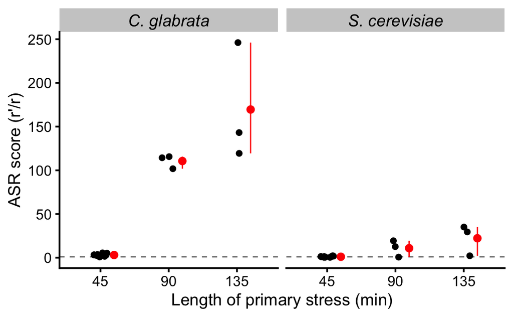

```r
p <- dat.s2 %>%
  #filter(!is.na(ASR_score)) %>%
  mutate(len_1 = factor(gsub(" ?min", "", Len_1), levels = c("45", "90", "135"))) %>%
  ggplot(aes(x = len_1, y = ASR_score)) + p.asr +
#  geom_hline(yintercept = 1, linetype = 2, color = "gray50") +
#  geom_point(position = position_jitter(width = 0.1), size = 2) +
#  stat_summary(position = position_nudge(x = 0.2),
#               fun.data = "mean_cl_boot", geom = "pointrange", color = "red") +
  xlab("Length of primary stress (min)") + ylab("ASR score (r'/r)") +
#  facet_wrap(~Species, scales = "free_x", labeller = as_labeller(species.label)) +
#  theme_cowplot(line_size = 0.7) +
  theme(legend.text = element_text(size = rel(1), face = 3),
        legend.position = c(0.1, 0.85),
        strip.text = element_text(size = rel(1), face = 3))
p
ggsave("../output/20230103-ASR-score-across-noPi-length-sc-cg.png", width = 5, height = 3)
```

#### Statistical summary and test

```r
dat.s2 %>%
  #filter(!low_count) %>%
  mutate(len_1 = factor(gsub(" ?min", "", Len_1), levels = c("45", "90", "135"))) %>%
  group_by(Species, len_1) %>%
  summarize(n = n(), ASR = mean(ASR_score), sd_asr = sd(ASR_score), .groups = "drop") %>%
  mutate(across(where(is.double), round, digits = 2))
```

| Species | len_1 | n | ASR | sd_asr |
| --- | --- | --- | --- | --- |
| Cg | 45 | 12 | 3.11 | 1.31 |
| Cg | 90 | 3 | 110.61 | 7.64 |
| Cg | 135 | 3 | 169.57 | 67.36 |
| Sc | 45 | 12 | 1.10 | 0.56 |
| Sc | 90 | 3 | 10.91 | 9.45 |
| Sc | 135 | 3 | 22.26 | 17.59 |

Because of the small sample size (3) for 90 and 135 minutes, Wilcoxon signed-rank test doesn’t have power to detect significant differences at any conventional size of the test (lower p-value for a sample size 3 is 0.25). Using t-test below, knowing that the normal assumption is likely not met. Overall, we should focus on the trend and not the statistical significance in this result.

```r
dat.s2 %>%
  ungroup() %>%
  mutate(len_1 = factor(gsub(" ?min", "", Len_1), levels = c("45", "90", "135"))) %>%
  select(Species, len_1, r, rp) %>%
  nest(data = c(r, rp)) %>%
  mutate(
    test = map(data, ~ t.test(.x$rp, .x$r, paired = TRUE, alternative = "g")),
    tidied = map(test, tidy)
  ) %>%
  unnest(tidied) %>%
  select(Species, len_1, p.value, method, alternative) %>%
  mutate(p.bonf = p.adjust(p.value, method = "bonf"),
         p.holm = p.adjust(p.value, method = "holm"),
         p.hoch = p.adjust(p.value, method = "hoch"),
         across(starts_with("p."), round, digits = 5)) %>%
  arrange(Species, len_1)
```

| Species | len_1 | p.value | method | alternative | p.bonf | p.holm | p.hoch |
| --- | --- | --- | --- | --- | --- | --- | --- |
| Cg | 45 | 0.00071 | Paired t-test | greater | 0.00424 | 0.00354 | 0.00354 |
| Cg | 90 | 0.00200 | Paired t-test | greater | 0.01201 | 0.00800 | 0.00800 |
| Cg | 135 | 0.00021 | Paired t-test | greater | 0.00125 | 0.00125 | 0.00125 |
| Sc | 45 | 0.83125 | Paired t-test | greater | 1.00000 | 0.83125 | 0.83125 |
| Sc | 90 | 0.11500 | Paired t-test | greater | 0.69003 | 0.25147 | 0.23001 |
| Sc | 135 | 0.08382 | Paired t-test | greater | 0.50293 | 0.25147 | 0.23001 |

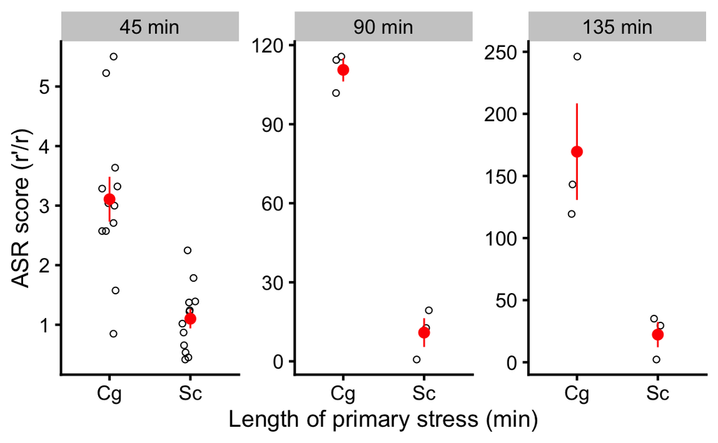

```r
p <- dat.s2 %>%
  #filter(!is.na(ASR_score)) %>%
  mutate(len_1 = factor(Len_1, levels = c("45 min", "90 min", "135 min"))) %>%
  ggplot(aes(x = Species, y = ASR_score)) +
  geom_point(#aes(fill = low_count),
    position = position_jitter(0.1), size = 1.5, shape = 21) +
  stat_summary(fun.data = "mean_se", geom = "pointrange", color = "red") +
  #scale_y_log10() +
  scale_shape_manual(values = c(21,22), labels = species.label) +
  #scale_fill_manual(values = c("white", "gray40"), guide = "none") +
  #facet_wrap(~Species, scales = "free_x", labeller = as_labeller(species.label)) +
  facet_wrap(~ len_1, scales = "free") +
  xlab("Length of primary stress (min)") + ylab("ASR score (r'/r)") +
  theme_cowplot(line_size = 0.7)
p
ggsave("../output/20230103-ASR-score-across-noPi-length-sep-panel.png", width = 6, height = 3)
```

## Fig3: cta1∆

**Goal**

- Determine if *CTA1* is required for the ASR

**Experiment**

- Jinye deleted *CTA1* and compared ASR in this strain to the wt *C. glabrata*

**Data**

| Species | Strain | Genotype | H2O2 |
| --- | --- | --- | --- |
| C. glabrata | yH001, yH002 | wildtype | 80, 100 mM |
| C. glabrata | yH271, yH272 | *cta1∆* | 2.2, 2.5 mM |

Six replicates, two each from 07/08, 07/11, 07/12 of 2022.

```r
use.f3 <- paste0(c("07/08", "07/11", "07/12"), "/22")
tmp <-  raw %>%
  filter(Date %in% use.f3) %>%
  mutate(
    scaled = Count * Dilutions * 1e-2
  ) %>%
  # remove uninformative columns. only one H2O2 conc used for each species
  select(-Len_1, -Len_2, -Experimenter)
# Assume the replicates were paired in the order they appear in the table,
# i.e., the first row in the MO, MM, PO, PM groups belong to the same biological
# replicate, we can derive three ASR_scores for each date x species x Len_1

dat.f3 <- tmp %>%
  # group by primary to calculate r (MO/MM) or r' (PO/PM)
  separate(Group, into = c("Primary", "Secondary"), sep = 1) %>%
  group_by(Date, Strain, Primary) %>%
  # calculate % survival
  mutate(r = num(scaled / scaled[Secondary == "M"], digits = 3)) %>%
  # remove the secondary mock as the information are all used
  filter(Secondary != "M")
dat.f3
```

| Date | Strain | Species | Genotype | Primary | Secondary | H2O2 | Dilutions | Count | scaled | r |
| --- | --- | --- | --- | --- | --- | --- | --- | --- | --- | --- |
| 07/12/22 | yH001 | Cg | wt | M | O | 80 mM | 1000 | 18 | 180 | 0.027 |
| 07/12/22 | yH001 | Cg | wt | M | O | 100 mM | 1000 | 3 | 30 | 0.004 |
| 07/12/22 | yH001 | Cg | wt | P | O | 80 mM | 1000 | 88 | 880 | 0.143 |
| 07/12/22 | yH001 | Cg | wt | P | O | 100 mM | 1000 | 61 | 610 | 0.099 |
| 07/12/22 | yH002 | Cg | wt | M | O | 80 mM | 1000 | 27 | 270 | 0.041 |
| 07/12/22 | yH002 | Cg | wt | M | O | 100 mM | 1000 | 7 | 70 | 0.011 |
| 07/12/22 | yH002 | Cg | wt | P | O | 80 mM | 1000 | 96 | 960 | 0.175 |
| 07/12/22 | yH002 | Cg | wt | P | O | 100 mM | 1000 | 48 | 480 | 0.088 |
| 07/12/22 | yH271 | Cg | cta1Δ | M | O | 2.2 mM | 1000 | 23 | 230 | 0.043 |
| 07/12/22 | yH271 | Cg | cta1Δ | M | O | 2.5 mM | 100 | 48 | 48 | 0.009 |

[output cut: 38 more lines]

### Plot (all data)

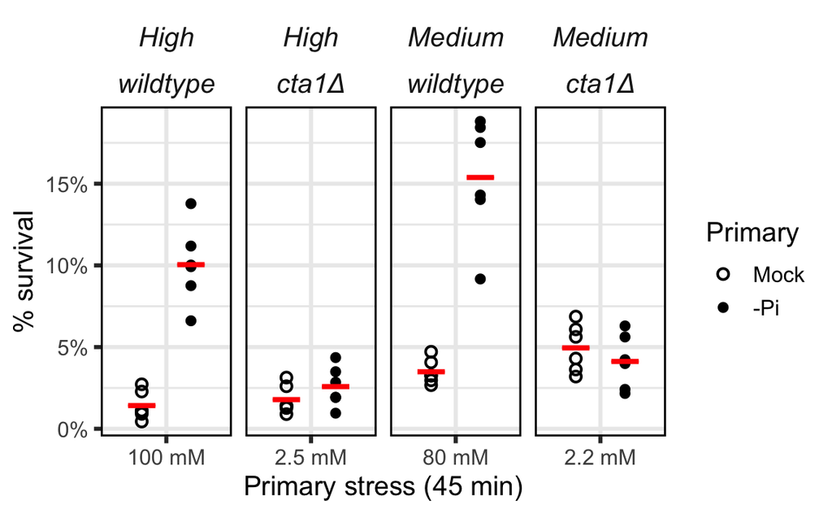

### 100 vs 2.5 mM

To be consistent with panel C, we will use the 100 mM vs 2.5 mM pair and leave out the 80 mM vs 2.2 mM pair.

```r
dat.f3a <- dat.f3 %>%
  mutate( Primary = factor(Primary, levels = c("M", "P"),
                           labels = c("Mock", "-Pi")),
          Genotype = factor(Genotype, levels = c("wt", "cta1Δ"),
                            labels = c("wildtype", "cta1Δ")),
          Group = factor(H2O2, levels = c("100 mM", "2.5 mM", "80 mM", "2.2 mM"),
                         labels = c("High", "High", "Medium", "Medium"))) %>%
  filter(Group == "High") %>%
  select(-Group) %>%
  ungroup()
write_tsv(dat.f3a, file = "../input/20230302-fig-3d-data-hb.tsv")
```

#### Plot

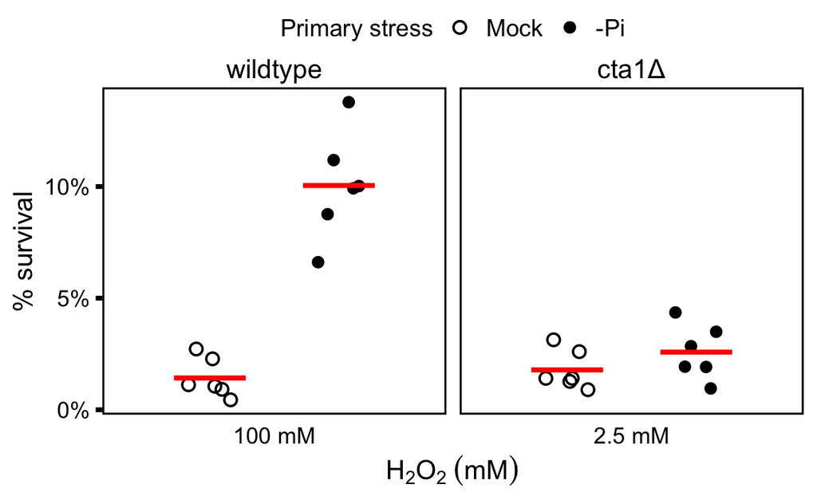

```r
p <- ggplot(dat.f3a, aes(x = H2O2, y = r)) +
  geom_point(aes(shape = Primary), stroke = 0.9, size = 2.5,
             position = position_jitterdodge(jitter.width = 0.3, dodge.width = 0.9)) +
  stat_summary(aes(group = Primary), position = position_dodge(0.9),
               fun = mean, fun.max = mean, fun.min = mean,
               geom = "crossbar", color = "red", width = 0.5) +
  facet_wrap(~ Genotype, nrow = 1, scales = "free_x") +
  scale_shape_manual(name = "Primary stress", values = c("Mock" = 1, "-Pi" = 16)) +
  scale_y_continuous(labels = scales::percent) +
  xlab(bquote(H[2]*O[2]~(mM))) + ylab("% survival") +
  theme_cowplot(line_size = 1.2) +
  panel_border(color = "black", size = 1) +
  theme(strip.text = element_text(size = rel(1)),
        strip.background = element_blank(),
        #strip.placement = "inside",
        axis.line = element_blank(),
        axis.ticks.x = element_blank(),
        legend.position = "top",
        legend.justification = "center",
        legend.margin = margin(b = -10),
        legend.text = element_text(size = rel(0.9)),
        legend.title = element_text(size = rel(0.9)))
p

ggsave("../output/20230301-fig3d-asr-cta1.png", width = 3.5, height = 3.5)
```

**Statistical tests**

#### Statistical test

1. Determine if the basal survival rates are different between species (Wilcoxon signed-rank test)
2. Determine if the primary stress enhanced the survival in *each* species (Wilcoxon signed-rank test)

**Basal survival rate**

Across species, unpaired, rank-sum test.

```r
tmp <- dat.f3a %>%
  filter(Primary == "Mock") %>%
  select(Date, Genotype, r) %>%
  arrange(Genotype)

tmp %>% group_by(Genotype) %>% summarize(mean = mean(r), sd = num(sd(r), digits = 3))
```

| Genotype | mean | sd |
| --- | --- | --- |
| wildtype | 0.014 | 0.009 |
| cta1Δ | 0.018 | 0.009 |

```r
wilcox.test(r ~ Genotype, paired = FALSE, data = tmp)
```

```
    Wilcoxon rank sum exact test

data:  r by Genotype
W = 12, p-value = 0.3939
alternative hypothesis: true location shift is not equal to 0
```

**Survival rate with the primary stress**

Across species, unpaired, rank-sum test.

```r
tmp <- dat.f3a %>%
  filter(Primary == "-Pi") %>%
  select(Date, Genotype, r) %>%
  arrange(Genotype)

tmp %>% group_by(Genotype) %>% summarize(mean = mean(r), sd = num(sd(r), digits = 3))
```

| Genotype | mean | sd |
| --- | --- | --- |
| wildtype | 0.100 | 0.024 |
| cta1Δ | 0.026 | 0.012 |

```r
wilcox.test(r ~ Genotype, paired = FALSE, data = tmp)
```

```
    Wilcoxon rank sum exact test

data:  r by Genotype
W = 36, p-value = 0.002165
alternative hypothesis: true location shift is not equal to 0
```

*Primary stress enhanced in wildtype*

Comparison between r and r’, paired, signed-rank test.

```r
tmp <- dat.f3a %>%
  filter(Genotype == "wildtype") %>%
  pivot_wider(id_cols = c(Date, Strain), names_from = Primary, values_from = r) %>%
  mutate(ASR = `-Pi`/Mock)

tmp
```

| Date | Strain | Mock | -Pi | ASR |
| --- | --- | --- | --- | --- |
| 07/12/22 | yH001 | 0.004 | 0.099 | 22.284 |
| 07/12/22 | yH002 | 0.011 | 0.088 | 8.309 |
| 07/11/22 | yH001 | 0.023 | 0.112 | 4.905 |
| 07/11/22 | yH002 | 0.011 | 0.138 | 12.313 |
| 07/08/22 | yH001 | 0.027 | 0.100 | 3.682 |
| 07/08/22 | yH002 | 0.009 | 0.066 | 7.238 |

```r
x <- Hmisc::smean.cl.boot(tmp$ASR)
sprintf("ASR_score mean = %.2f, 95%% CI by bootstrap = [%.2f, %.2f]", x[1], x[2], x[3])
```

```
[1] "ASR_score mean = 9.79, 95% CI by bootstrap = [5.48, 15.19]"
```

```r
with(tmp, t.test(as.numeric(`-Pi`), as.numeric(Mock), paired = TRUE, alternative = "g"))
```

```
    Paired t-test

data:  as.numeric(`-Pi`) and as.numeric(Mock)
t = 8.8845, df = 5, p-value = 0.0001503
alternative hypothesis: true mean difference is greater than 0
95 percent confidence interval:
 0.0666749       Inf
sample estimates:
mean difference
     0.08623283
```

```r
with(tmp, wilcox.test(`-Pi`, Mock, paired = TRUE, alternative = "g"))
```

```
    Wilcoxon signed rank exact test

data:  -Pi and Mock
V = 21, p-value = 0.01563
alternative hypothesis: true location shift is greater than 0
```

```r
with(tmp, wilcox.test(`-Pi`, Mock, paired = FALSE, alternative = "g"))
```

```
    Wilcoxon rank sum exact test

data:  -Pi and Mock
W = 36, p-value = 0.001082
alternative hypothesis: true location shift is greater than 0
```

Paired, signed-rank test

```r
tmp <- dat.f3a %>%
  filter(Genotype == "cta1Δ") %>%
  pivot_wider(id_cols = c(Date, Strain), names_from = Primary, values_from = r) %>%
  mutate(ASR = `-Pi`/Mock)

tmp
```

| Date | Strain | Mock | -Pi | ASR |
| --- | --- | --- | --- | --- |
| 07/12/22 | yH271 | 0.009 | 0.010 | 1.064 |
| 07/12/22 | yH272 | 0.014 | 0.019 | 1.372 |
| 07/11/22 | yH271 | 0.013 | 0.028 | 2.241 |
| 07/11/22 | yH272 | 0.014 | 0.019 | 1.363 |
| 07/08/22 | yH271 | 0.031 | 0.035 | 1.115 |
| 07/08/22 | yH272 | 0.026 | 0.044 | 1.675 |

```r
x <- Hmisc::smean.cl.boot(tmp$ASR)
sprintf("ASR_score mean = %.2f, 95%% CI by bootstrap = [%.2f, %.2f]", x[1], x[2], x[3])
```

```
[1] "ASR_score mean = 1.47, 95% CI by bootstrap = [1.18, 1.80]"
```

```r
with(tmp, t.test(as.numeric(`-Pi`), as.numeric(Mock), paired = TRUE, alternative = "g"))
```

```
    Paired t-test

data:  as.numeric(`-Pi`) and as.numeric(Mock)
t = 2.8069, df = 5, p-value = 0.01884
alternative hypothesis: true mean difference is greater than 0
95 percent confidence interval:
 0.002249032         Inf
sample estimates:
mean difference
    0.007972278
```

```r
with(tmp, wilcox.test(`-Pi`, Mock, paired = TRUE, alternative = "g"))
```

```
    Wilcoxon signed rank exact test

data:  -Pi and Mock
V = 21, p-value = 0.01563
alternative hypothesis: true location shift is greater than 0
```

```r
with(tmp, wilcox.test(`-Pi`, Mock, paired = FALSE, alternative = "g"))
```

```
    Wilcoxon rank sum exact test

data:  -Pi and Mock
W = 26, p-value = 0.1201
alternative hypothesis: true location shift is greater than 0
```

### 80 vs 2.2 mM

Corresponding results for 80 mM vs 2.2 mM

```r
dat.s3b <- dat.f3 %>%
  mutate( Primary = factor(Primary, levels = c("M", "P"),
                           labels = c("Mock", "-Pi")),
          Genotype = factor(Genotype, levels = c("wt", "cta1Δ"),
                            labels = c("wildtype", "cta1Δ")),
          Group = factor(H2O2, levels = c("100 mM", "2.5 mM", "80 mM", "2.2 mM"),
                         labels = c("High", "High", "Medium", "Medium"))) %>%
  filter(Group == "Medium") %>%
  ungroup()
```

#### Plot

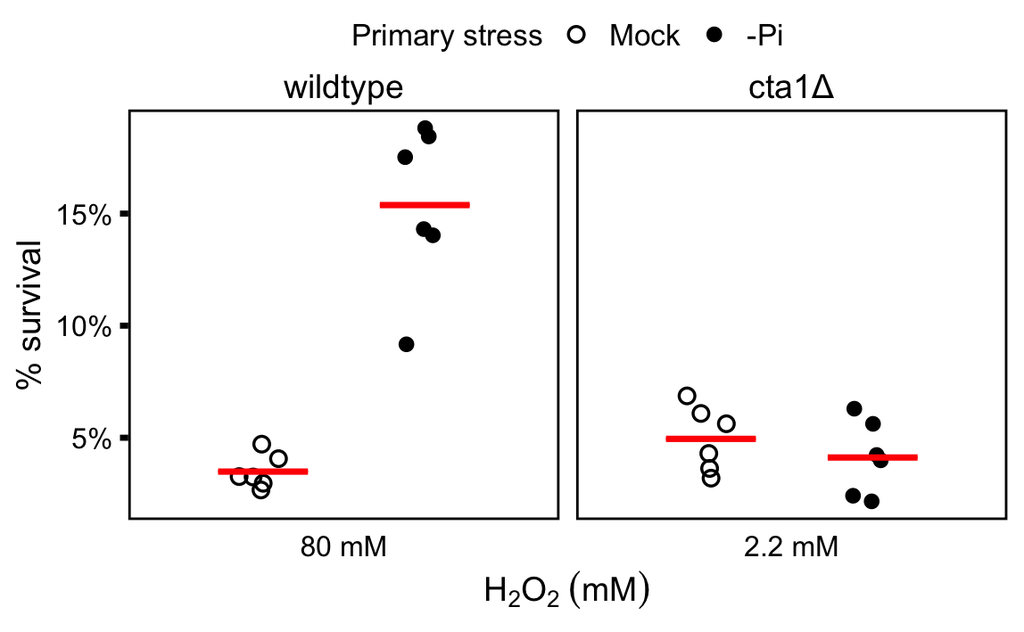

```r
p <- ggplot(dat.s3b, aes(x = H2O2, y = r)) +
  geom_point(aes(shape = Primary), stroke = 0.9, size = 2.5,
             position = position_jitterdodge(jitter.width = 0.3, dodge.width = 0.9)) +
  stat_summary(aes(group = Primary), position = position_dodge(0.9),
               fun = mean, fun.max = mean, fun.min = mean,
               geom = "crossbar", color = "red", width = 0.5) +
  facet_wrap(~ Genotype, nrow = 1, scales = "free_x") +
  scale_shape_manual(name = "Primary stress", values = c("Mock" = 1, "-Pi" = 16)) +
  scale_y_continuous(labels = scales::percent) +
  xlab(bquote(H[2]*O[2]~(mM))) + ylab("% survival") +
  theme_cowplot(line_size = 1.2) +
  panel_border(color = "black", size = 1) +
  theme(strip.text = element_text(size = rel(1)),
        strip.background = element_blank(),
        #strip.placement = "inside",
        axis.line = element_blank(),
        axis.ticks.x = element_blank(),
        legend.position = "top",
        legend.justification = "center",
        legend.margin = margin(b = -10),
        legend.text = element_text(size = rel(0.9)),
        legend.title = element_text(size = rel(0.9)))
p

ggsave("../output/20230301-s3b-asr-cta1.png", width = 3.5, height = 3.5)
```

**Statistical tests**

#### Statistical test

1. Determine if the basal survival rates are different between species (Wilcoxon signed-rank test)
2. Determine if the primary stress enhanced the survival in *each* species (Wilcoxon signed-rank test)

*Basal survival rate* Across species, unpaired, rank-sum test.

```r
tmp <- dat.s3b %>%
  filter(Primary == "Mock") %>%
  select(Date, Genotype, r) %>%
  arrange(Genotype)
tmp %>% group_by(Genotype) %>% summarize(mean = mean(r), sd = num(sd(r), digits = 3))
```

| Genotype | mean | sd |
| --- | --- | --- |
| wildtype | 0.035 | 0.008 |
| cta1Δ | 0.049 | 0.015 |

```r
wilcox.test(r ~ Genotype, paired = FALSE, data = tmp)
```

```
    Wilcoxon rank sum exact test

data:  r by Genotype
W = 7, p-value = 0.09307
alternative hypothesis: true location shift is not equal to 0
```

*Primary stress enhanced in wildtype*

Comparison between r and r’, paired, signed-rank test.

```r
tmp <- dat.s3b %>%
  filter(Genotype == "wildtype") %>%
  pivot_wider(id_cols = c(Date, Strain), names_from = Primary, values_from = r) %>%
  mutate(ASR = `-Pi`/Mock)

tmp
```

| Date | Strain | Mock | -Pi | ASR |
| --- | --- | --- | --- | --- |
| 07/12/22 | yH001 | 0.027 | 0.143 | 5.358 |
| 07/12/22 | yH002 | 0.041 | 0.175 | 4.308 |
| 07/11/22 | yH001 | 0.047 | 0.184 | 3.912 |
| 07/11/22 | yH002 | 0.032 | 0.188 | 5.790 |
| 07/08/22 | yH001 | 0.033 | 0.140 | 4.295 |
| 07/08/22 | yH002 | 0.030 | 0.092 | 3.089 |

```r
x <- Hmisc::smean.cl.boot(tmp$ASR)
sprintf("ASR_score mean = %.2f, 95%% CI by bootstrap = [%.2f, %.2f]", x[1], x[2], x[3])
```

```
[1] "ASR_score mean = 4.46, 95% CI by bootstrap = [3.77, 5.16]"
```

```r
with(tmp, t.test(as.numeric(`-Pi`), as.numeric(Mock), paired = TRUE, alternative = "g"))
```

```
    Paired t-test

data:  as.numeric(`-Pi`) and as.numeric(Mock)
t = 8.9447, df = 5, p-value = 0.0001455
alternative hypothesis: true mean difference is greater than 0
95 percent confidence interval:
 0.09212352        Inf
sample estimates:
mean difference
      0.1189116
```

```r
with(tmp, wilcox.test(`-Pi`, Mock, paired = TRUE, alternative = "g"))
```

```
    Wilcoxon signed rank exact test

data:  -Pi and Mock
V = 21, p-value = 0.01563
alternative hypothesis: true location shift is greater than 0
```

```r
with(tmp, wilcox.test(`-Pi`, Mock, paired = FALSE, alternative = "g"))
```

```
    Wilcoxon rank sum exact test

data:  -Pi and Mock
W = 36, p-value = 0.001082
alternative hypothesis: true location shift is greater than 0
```

*Primary stress no effect in cta1Δ*

Paired, signed-rank test

```r
tmp <- dat.s3b %>%
  filter(Genotype == "cta1Δ") %>%
  pivot_wider(id_cols = c(Date, Strain), names_from = Primary, values_from = r) %>%
  mutate(ASR = `-Pi`/Mock)

tmp
```

| Date | Strain | Mock | -Pi | ASR |
| --- | --- | --- | --- | --- |
| 07/12/22 | yH271 | 0.043 | 0.022 | 0.503 |
| 07/12/22 | yH272 | 0.056 | 0.024 | 0.429 |
| 07/11/22 | yH271 | 0.036 | 0.042 | 1.166 |
| 07/11/22 | yH272 | 0.061 | 0.056 | 0.924 |
| 07/08/22 | yH271 | 0.069 | 0.040 | 0.581 |
| 07/08/22 | yH272 | 0.032 | 0.063 | 1.970 |

```r
x <- Hmisc::smean.cl.boot(tmp$ASR)
sprintf("ASR_score mean = %.2f, 95%% CI by bootstrap = [%.2f, %.2f]", x[1], x[2], x[3])
```

```
[1] "ASR_score mean = 0.93, 95% CI by bootstrap = [0.56, 1.38]"
```

```r
with(tmp, t.test(as.numeric(`-Pi`), as.numeric(Mock), paired = TRUE, alternative = "g"))
```

```
    Paired t-test

data:  as.numeric(`-Pi`) and as.numeric(Mock)
t = -0.84267, df = 5, p-value = 0.7811
alternative hypothesis: true mean difference is greater than 0
95 percent confidence interval:
 -0.02818646         Inf
sample estimates:
mean difference
    -0.00831149
```

```r
with(tmp, wilcox.test(`-Pi`, Mock, paired = TRUE, alternative = "g"))
```

```
    Wilcoxon signed rank exact test

data:  -Pi and Mock
V = 7, p-value = 0.7812
alternative hypothesis: true location shift is greater than 0
```

```r
with(tmp, wilcox.test(`-Pi`, Mock, paired = FALSE, alternative = "g"))
```

```
    Wilcoxon rank sum exact test

data:  -Pi and Mock
W = 12, p-value = 0.8452
alternative hypothesis: true location shift is greater than 0
```

## Fig6: ASR by rapamycin

**Goal**

- Test the hypothesis that direct inhibition of TORC1 can provide ASR in *C. glabrata*. We will also test *S. cerevisiae* to determine if the negative regulation by TORC1 on stress response genes behind the ASR is conserved.

**Data**

[output not shown]

| Date | Species | Rapa (ng/mL) | H2O2 | Strain |
| --- | --- | --- | --- | --- |
| 01/12/23 | Cg | 62.5, 125 | 60 mM | yH181 |
| 01/18/23 | Cg | 62.5, 125 | 60 mM | yH181 |
| 01/21/23 | Sc | 62.5, 125 | 4, 6 mM | yH154 |
| 01/21/23 | Cg | 62.5, 125 | 40, 60 mM | yH181 |
| 01/25/23 | Sc | 62.5, 125 | 4, 6 mM | yH154 |
| 01/25/23 | Cg | 62.5, 125 | 40, 60 mM | yH181 |
| 01/26/23 | Sc | 62.5, 125 | 4, 6 mM | yH154 |
| 01/26/23 | Cg | 62.5, 125 | 40, 60 mM | yH181 |
| 01/31/23 | Sc | 62.5, 125 | 4, 6 mM | yH154 |
| 01/31/23 | Cg | 62.5, 125 | 40, 60 mM | yH181 |
| 02/02/23 | Cg | 62.5, 125 | 40, 60 mM | yH181 |

**Note**

Jinye used lower H2O2 concentration compared with preivous ASR experiments (100 mM for Cg and 10 mM for Sc) because the primary stresses tested here, i.e., rapamycin and nitrogen starvation, reduced survival while phosphate starvation used in previous ASR experiments didn’t. In order to maintain a similar CFU at the end, a lower H2O2 concentration was applied.

```r
dat.6 <- read_csv("../input/20230205-Sc-Cg-rapamycin-nitrogen-ASR-raw.csv", col_types = cols(), comment = "#") %>%
  mutate(Date = gsub("d(\\d\\d)(\\d\\d)(\\d\\d)", "\\1/\\2/\\3", Date))

# data sanity check, quick view
sapply(select(dat.6, Species, Strain, Genotype), unique)
```

```
$Species
[1] "Cg" "Sc"

$Strain
[1] "yH181" "yH154"

$Genotype
[1] "wt"
```

**Plotting**

### Effect of primary stress (Rapamycin and -N) on survival

Jinye mentioned that unlike phosphate starvation, rapamycin and nitrogen starvation reduce survival by themselves. To see this myself, I’m plotting the CFU after just the primary

```r
tmp <- dat.6 %>%
  filter(H2O2 == "Mock") %>%
  group_by(Date, Species) %>%
  mutate(
    # arbitrarily decide any CFU counts < 3 are not included due to high CV
    Count = ifelse(Count < 3, NA, Count),
    scaled = Count * Dilutions * 1e-2,
    r = scaled / scaled[`1st_Stress` == "Mock"]
  ) %>%
  ungroup() %>%
  filter(`1st_Stress` != "Mock") %>%
  select(Date, Species, Strain, Primary = `1st_Stress`, Count, r)

dat.Prim <-  raw %>%
  separate(Group, into = c("Primary", "Secondary"), sep = 1) %>%
  # use the S2 dataset to examine the effect of phosphate starvation on survival
  filter(Date %in% use.s1b, Secondary == "M") %>%
  mutate(
    # arbitrarily decide any CFU counts < 3 are not included due to high CV
    Count = ifelse(Count < 3, NA, Count),
    scaled = Count * Dilutions * 1e-2
  ) %>%
  group_by(Date, Strain) %>%
  # calculate r and r'
  mutate(r = scaled / scaled[Primary == "M"]) %>%
  ungroup() %>% filter(Primary != "M") %>%
  select(Date, Species, Strain, Primary, Count, r) %>%
  bind_rows(tmp) %>%
  mutate(Primary = factor(Primary,
                          levels = c("P", "62.5", "125", "0Ni"),
                          labels = c("-Pi", "Rapa\n62.5",
                                     "Rapa\n125", "-Nitrogen")))
```

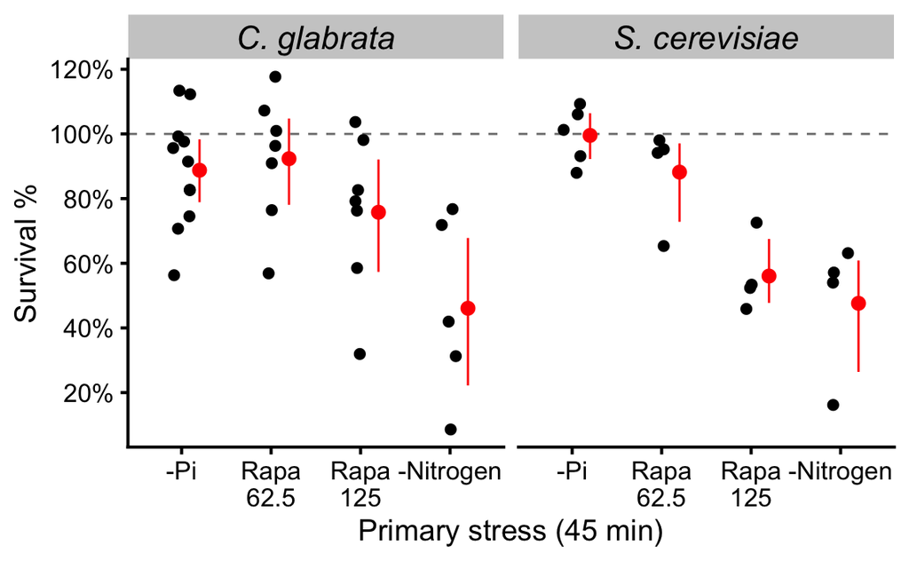

**Statistical tests**

Use the [nest-map-unnest workflow](https://broom.tidymodels.org/articles/broom_and_dplyr.html)

```r
dat.Prim %>%
  select(Species, Primary, r) %>%
  nest(data = r) %>%
  mutate(
    test = map(data, ~ t.test(.x, mu = 1, alternative = "two")),
    tidied = map(test, tidy)
  ) %>%
  unnest(tidied) %>%
  select(Species, Primary, mean_r = estimate, p.value, conf.low, conf.high, alternative) %>%
  mutate(P.adj = p.adjust(p.value, method = "BH"),
         across(where(is.numeric), round, digits = 3)) %>%
  arrange(Species, Primary)
```

| Species | Primary | mean_r | p.value | conf.low | conf.high | alternative | P.adj |
| --- | --- | --- | --- | --- | --- | --- | --- |
| Cg | -Pi | 0.888 | 0.059 | 0.770 | 1.005 | two.sided | 0.095 |
| Cg | Rapa\n62.5 | 0.923 | 0.357 | 0.736 | 1.111 | two.sided | 0.407 |
| Cg | Rapa\n125 | 0.758 | 0.039 | 0.533 | 0.983 | two.sided | 0.078 |
| Cg | -Nitrogen | 0.461 | 0.013 | 0.107 | 0.815 | two.sided | 0.043 |
| Sc | -Pi | 0.995 | 0.914 | 0.885 | 1.106 | two.sided | 0.914 |
| Sc | Rapa\n62.5 | 0.882 | 0.221 | 0.638 | 1.126 | two.sided | 0.294 |
| Sc | Rapa\n125 | 0.560 | 0.005 | 0.378 | 0.743 | two.sided | 0.037 |
| Sc | -Nitrogen | 0.476 | 0.016 | 0.137 | 0.815 | two.sided | 0.043 |

### Calibrate secondary stress strength

Jinye used two sets of H2O2 concentrations in this experiment, i.e., 40/4 mM and 60/6 mM for *C. glabrata* and *S. cerevisiae*, respectively.

```r
with(dat.6, table(Date, paste(Species, H2O2, sep = ":")))
```

```
Date       Cg:40mM Cg:60mM Cg:Mock Sc:4mM Sc:6mM Sc:Mock
  01/12/23       0       3       3      0      0       0
  01/18/23       0       3       3      0      0       0
  01/21/23       4       4       4      4      4       4
  01/25/23       4       4       4      4      4       4
  01/26/23       4       4       4      4      4       4
  01/31/23       4       4       4      4      4       4
  02/02/23       4       4       4      0      0       0
```

First, we will test if the survival under these H2O2 concentrations are comparable across species, by analyzing the basal survival rate r

Statistical test for differences in basal survival between species at 60 or 6 mM. A Wilcoxon signed-rank test is used here since the two groups are dependent (=grouped) by the day of the experiment. One replicate was run per day. Using a paired-test ensures that day-to-day variation is accounted for.

```r
tmp <- dat.6 %>%
  filter(H2O2 %in% c("60mM", "6mM"), Group == "MO",
         !(Date %in% c("01/12/23", "01/18/23", "02/02/23")))# %>%
tmp %>% group_by(Species) %>% summarize(mean = mean(`MO/MM`))
```

| Species | mean |
| --- | --- |
| Cg | 0.03031831 |
| Sc | 0.04949495 |

```r
wilcox.test(`MO/MM` ~ Species, data = tmp, paired = TRUE)
```

```
    Wilcoxon signed rank exact test

data:  MO/MM by Species
V = 3, p-value = 0.625
alternative hypothesis: true location shift is not equal to 0
```

Statistical test for differences in basal survival between species at 40 or 4 mM.

```r
tmp <- dat.6 %>%
  filter(H2O2 %in% c("40mM", "4mM"), Group == "MO", !(Date %in% c("02/02/23")))
tmp %>% group_by(Species) %>% summarize(mean = mean(`MO/MM`))
```

| Species | mean |
| --- | --- |
| Cg | 0.06057018 |
| Sc | 0.08569350 |

```r
wilcox.test(`MO/MM` ~ Species, data = tmp, paired = TRUE)
```

```
    Wilcoxon signed rank exact test

data:  MO/MM by Species
V = 1, p-value = 0.25
alternative hypothesis: true location shift is not equal to 0
```

Statistical test for differences in basal survival between the high and low H2O2 concentrations (60/6 vs 40/4 mM), species combined.

```r
tmp <- filter(dat.6, Group == "MO") %>%
  mutate(secondary = factor(H2O2, levels = c("60mM", "6mM", "40mM", "4mM"),
                            labels = c("high", "high", "low", "low")))
tmp %>%
  group_by(secondary, Species) %>%
  summarize(mean = num(mean(`MO/MM`), digits = 3), .groups = "drop")
```

| secondary | Species | mean |
| --- | --- | --- |
| high | Cg | 0.039 |
| high | Sc | 0.049 |
| low | Cg | 0.081 |
| low | Sc | 0.086 |

```r
wilcox.test(`MO/MM` ~ secondary, data = tmp, paired = FALSE)
```

```
    Wilcoxon rank sum exact test

data:  MO/MM by secondary
W = 21, p-value = 0.03103
alternative hypothesis: true location shift is not equal to 0
```

```r
anova(lm(`MO/MM` ~ Species + secondary, data = tmp))
```

```
Analysis of Variance Table

Response: MO/MM
          Df    Sum Sq   Mean Sq F value  Pr(>F)
Species    1 0.0006071 0.0006071  0.3490 0.56246
secondary  1 0.0078300 0.0078300  4.5011 0.04887 *
Residuals 17 0.0295725 0.0017396
---
Signif. codes:  0 ‘***’ 0.001 ‘**’ 0.01 ‘*’ 0.05 ‘.’ 0.1 ‘ ’ 1
```

> We can conclude that there is no significant difference in survival when comparing 40 mM vs 4 mM for *C. glabrata* vs *S. cerevisiae*. Similarly, there is no significant difference in survival when 60 mM and 6 mM were used to treat the two species, respectively. However, the survival rate is significantly lower under the higher set of concentrations (60 and 6 mM) compared with the lower ones (40 and 4 mM)

### Rapamycin ASR

```r
# we will not use the days of experiments where only one species was assayed
dat.6p <- filter(dat.6, H2O2 != "Mock") %>% # remove the XM groups
  rename(primary = `1st_Stress`, r = `MO/MM`, rP = `PO/PM`) %>%
  group_by(Date, Strain, H2O2) %>% # form groups to apply the same MO/MM
  mutate(r = r[primary == "Mock"], # MO/MM for each group
         secondary =
           factor(H2O2, levels = c("40mM", "4mM", "60mM", "6mM"),
                  labels = c("40/4mM", "40/4mM", "60/6mM", "60/6mM"))) %>%
  ungroup() %>%
  filter(!is.na(rP))
```

my calculation is the same as JY’s

```r
with(dat.6p, sum(round(rP/r, 5) != round(ASR_Score, 5)))
```

```
[1] 0
```

#### Plot

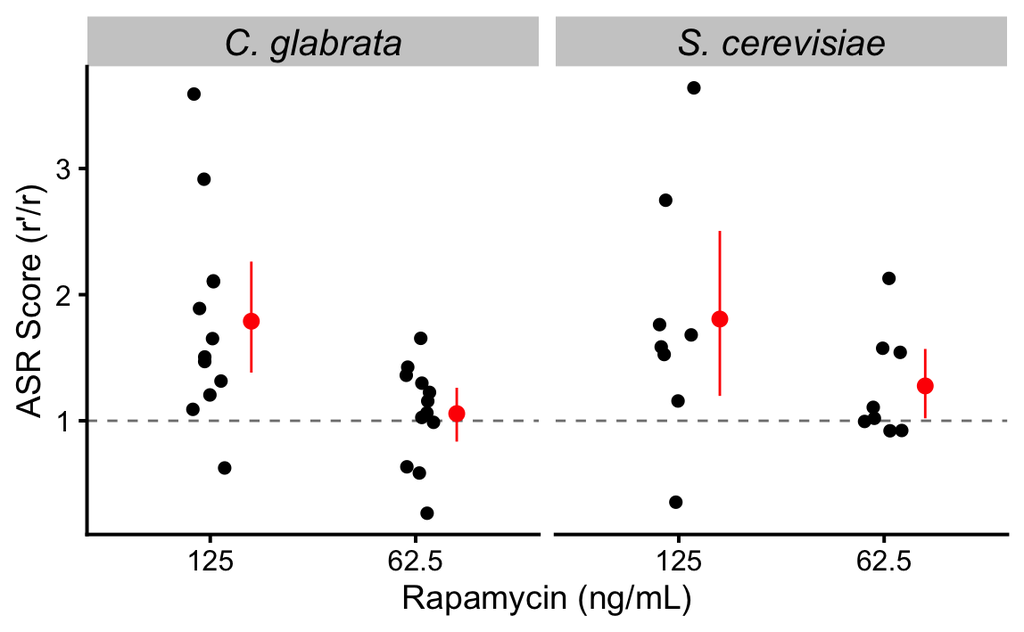

#### Statistical test

Summary statistics

```r
dat.6p %>%
  #filter(secondary == "60/6mM") %>%
  group_by(Species, primary) %>%
  summarize(
    # smean.cl.boot returns a named vector. t() %>% as_tibble() turns it
    # into a one-row tibble, stored as a list column. unnest() then flattens
    # the list-column back out into regular columns
    test = Hmisc::smean.cl.boot(ASR_Score) %>% t() %>% as_tibble()
  ) %>%
  unnest(test) %>%
  mutate(across(where(is.numeric), round, digits = 2))
```

| Species | primary | Mean | Lower | Upper |
| --- | --- | --- | --- | --- |
| Cg | 0Ni | 1.55 | 0.80 | 2.51 |
| Cg | 125 | 1.79 | 1.35 | 2.28 |
| Cg | 62.5 | 1.06 | 0.83 | 1.27 |
| Sc | 0Ni | 2.49 | 1.50 | 3.62 |
| Sc | 125 | 1.81 | 1.21 | 2.47 |
| Sc | 62.5 | 1.28 | 1.03 | 1.57 |

Wilcoxon signed-rank test comparing r’ and r (paired data)

```r
dat.6p %>%
  filter(primary != "0Ni") %>%
  select(Species, primary, r, rP) %>%
  nest(data = c(r, rP)) %>%
  mutate(
    test = map(data, ~ wilcox.test(.x$rP, .x$r, paired = TRUE, alternative = "g")),
    tidied = map(test, tidy)
  ) %>%
  unnest(tidied) %>%
  select(Species, primary, T = statistic, p.value, method, alternative) %>%
  mutate(p.bonf = p.adjust(p.value, method = "bonf"),
         p.holm = p.adjust(p.value, method = "holm"),
         p.hoch = p.adjust(p.value, method = "hoch"),
         across(starts_with("p."), round, digits = 5))
```

| Species | primary | T | p.value | method | alternative | p.bonf | p.holm | p.hoch |
| --- | --- | --- | --- | --- | --- | --- | --- | --- |
| Cg | 62.5 | 49 | 0.23486 | Wilcoxon signed rank exact test | greater | 0.93945 | 0.31250 | 0.23486 |
| Cg | 125 | 77 | 0.00049 | Wilcoxon signed rank exact test | greater | 0.00195 | 0.00195 | 0.00195 |
| Sc | 62.5 | 26 | 0.15625 | Wilcoxon signed rank exact test | greater | 0.62500 | 0.31250 | 0.23486 |
| Sc | 125 | 30 | 0.05469 | Wilcoxon signed rank exact test | greater | 0.21875 | 0.16406 | 0.16406 |

Paired t-tests comparing r’ and r

```r
dat.6p %>%
  #filter(primary != "0Ni") %>%
  select(Species, primary, r, rP) %>%
  nest(data = c(r, rP)) %>%
  mutate(
    test = map(data, ~ t.test(.x$rP, .x$r, paired = TRUE, alternative = "g")),
    tidied = map(test, tidy)
  ) %>%
  unnest(tidied) %>%
  select(Species, primary, p.value, method, alternative) %>%
  mutate(P.adj = p.adjust(p.value, method = "BH"),
         across(where(is.numeric), round, digits = 3))
```

| Species | primary | p.value | method | alternative | P.adj |
| --- | --- | --- | --- | --- | --- |
| Cg | 62.5 | 0.466 | Paired t-test | greater | 0.466 |
| Cg | 125 | 0.001 | Paired t-test | greater | 0.009 |
| Cg | 0Ni | 0.179 | Paired t-test | greater | 0.214 |
| Sc | 62.5 | 0.081 | Paired t-test | greater | 0.162 |
| Sc | 125 | 0.113 | Paired t-test | greater | 0.170 |
| Sc | 0Ni | 0.045 | Paired t-test | greater | 0.134 |

> In conclusion, we found significant ASR effect at 125 ng/mL rapamycin treatment in *C. glabrata* using either a Wilcoxon signed-rank test (nonparametric) or a paired t test, both using a 0.05 rejection threhold. We couldn’t reject the null hypothesis of no survival difference between rapamycin treated vs untreated samples for the 62.5 ng/mL concentration, and also not for the higher dose in *S. cerevisiae*